# Practical in model selection

Iliana Vasiliki Ntinou

6/4/2021

## hypothesis testing

### Import the palmerpenguin data and load libraries

```r
#instal the package with: install.packages("palmerpenguins")
data("penguins", package="palmerpenguins")
penguins
```

```
## # A tibble: 344 x 8
##    species island    bill_length_mm bill_depth_mm flipper_length_mm body_mass_g
##    <fct>   <fct>              <dbl>         <dbl>             <int>       <int>
##  1 Adelie  Torgersen           39.1          18.7               181        3750
##  2 Adelie  Torgersen           39.5          17.4               186        3800
##  3 Adelie  Torgersen           40.3          18                 195        3250
##  4 Adelie  Torgersen           NA            NA                  NA          NA
##  5 Adelie  Torgersen           36.7          19.3               193        3450
##  6 Adelie  Torgersen           39.3          20.6               190        3650
##  7 Adelie  Torgersen           38.9          17.8               181        3625
##  8 Adelie  Torgersen           39.2          19.6               195        4675
##  9 Adelie  Torgersen           34.1          18.1               193        3475
## 10 Adelie  Torgersen           42            20.2               190        4250
## # ... with 334 more rows, and 2 more variables: sex <fct>, year <int>
```

```r
#drop the NA values
penguins <- na.omit(penguins)
#libraries
library(tidyverse)
library(nlme)
```

### Test the hypothesis that bill length differs between species.

```r
lm1 <- lm(bill_length_mm ~ species, data = penguins)
anova(lm1)
```

```
## Analysis of Variance Table
##
## Response: bill_length_mm
##            Df Sum Sq Mean Sq F value    Pr(>F)
## species     2 7015.4  3507.7   397.3 < 2.2e-16 ***
## Residuals 330 2913.5     8.8
## ---
## Signif. codes:  0 '***' 0.001 '**' 0.01 '*' 0.05 '.' 0.1 ' ' 1
```

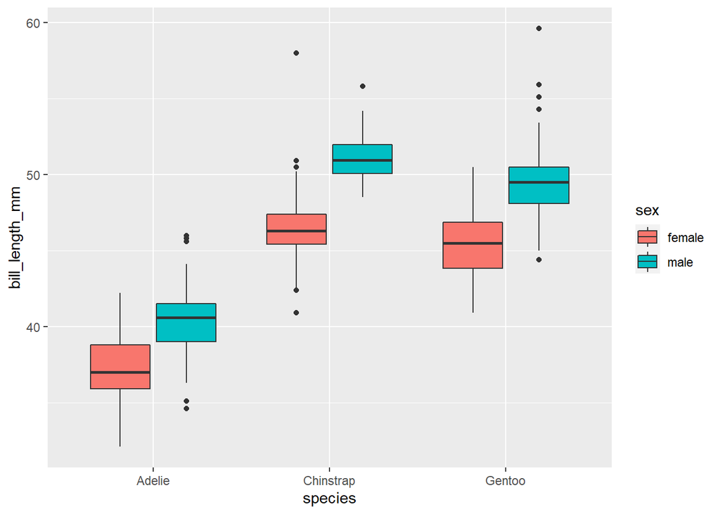

```r
penguins %>%
  ggplot(aes(x = species, y = bill_length_mm, fill = sex)) +
  geom_boxplot()
```

### Test the hypothesis that bill length differs by sex in addition to species.How should the p-values be interpreted?

```r
lm1 <- lm(bill_length_mm ~ species, data = penguins)
lm2 <- lm(bill_length_mm ~ species + sex, data = penguins)
anova(lm1, lm2)
```

```
## Analysis of Variance Table
##
## Model 1: bill_length_mm ~ species
## Model 2: bill_length_mm ~ species + sex
##   Res.Df    RSS Df Sum of Sq      F    Pr(>F)
## 1    330 2913.5
## 2    329 1777.8  1    1135.7 210.17 < 2.2e-16 ***
## ---
## Signif. codes:  0 '***' 0.001 '**' 0.01 '*' 0.05 '.' 0.1 ' ' 1
```

So we conclude from the p value that the second mdel with the sex is better. So bill length is also affected by the sex.

## Exploratory model building

Normally you would be doing this on a separate data set

### Use forward selection to find the best model to explain bill length.

```r
library(MASS)
mod <- lm(bill_length_mm ~.^2, data=penguins)
summary(mod)
```

```
##
## Call:
## lm(formula = bill_length_mm ~ .^2, data = penguins)
##
## Residuals:
##     Min      1Q  Median      3Q     Max
## -5.5767 -1.2230 -0.0192  1.1675 10.4034
##
## Coefficients: (4 not defined because of singularities)
##                                      Estimate Std. Error t value Pr(>|t|)
## (Intercept)                        -4.540e+03  1.140e+04  -0.398   0.6907
## speciesChinstrap                   -1.250e+03  1.152e+03  -1.085   0.2790
## speciesGentoo                       3.685e+03  3.397e+03   1.085   0.2789
## islandDream                         2.574e+03  1.434e+03   1.794   0.0738 .
## islandTorgersen                     2.907e+03  1.593e+03   1.825   0.0690 .
## bill_depth_mm                       5.840e+02  4.546e+02   1.284   0.2000
## flipper_length_mm                  -4.392e+01  6.288e+01  -0.698   0.4854
## body_mass_g                         2.275e-01  1.180e+00   0.193   0.8473
## sexmale                            -5.918e+02  1.039e+03  -0.570   0.5692
## year                                2.281e+00  5.684e+00   0.401   0.6884
## speciesChinstrap:islandDream               NA         NA      NA       NA
## speciesGentoo:islandDream                  NA         NA      NA       NA
## speciesChinstrap:islandTorgersen           NA         NA      NA       NA
## speciesGentoo:islandTorgersen              NA         NA      NA       NA
## speciesChinstrap:bill_depth_mm      4.294e-01  5.697e-01   0.754   0.4516
## speciesGentoo:bill_depth_mm         4.134e-01  1.154e+00   0.358   0.7205
## speciesChinstrap:flipper_length_mm -3.657e-02  8.407e-02  -0.435   0.6639
## speciesGentoo:flipper_length_mm     1.352e-01  2.091e-01   0.647   0.5183
## speciesChinstrap:body_mass_g        4.267e-04  1.705e-03   0.250   0.8025
## speciesGentoo:body_mass_g           1.237e-03  3.913e-03   0.316   0.7521
## speciesChinstrap:sexmale            3.036e-01  1.446e+00   0.210   0.8338
## speciesGentoo:sexmale              -7.297e+00  3.576e+00  -2.041   0.0422 *
## speciesChinstrap:year               6.262e-01  5.751e-01   1.089   0.2771
## speciesGentoo:year                 -1.850e+00  1.698e+00  -1.090   0.2767
## islandDream:bill_depth_mm           4.178e-01  5.493e-01   0.761   0.4475
## islandTorgersen:bill_depth_mm      -7.707e-01  5.910e-01  -1.304   0.1933
## islandDream:flipper_length_mm       3.568e-02  9.267e-02   0.385   0.7005
## islandTorgersen:flipper_length_mm   1.021e-01  9.937e-02   1.027   0.3051
## islandDream:body_mass_g            -8.926e-04  1.805e-03  -0.495   0.6213
## islandTorgersen:body_mass_g        -1.385e-03  1.778e-03  -0.779   0.4366
## islandDream:sexmale                -5.886e-01  1.443e+00  -0.408   0.6837
## islandTorgersen:sexmale             1.133e+00  1.658e+00   0.683   0.4952
## islandDream:year                   -1.287e+00  7.175e-01  -1.794   0.0738 .
## islandTorgersen:year               -1.448e+00  7.950e-01  -1.821   0.0696 .
## bill_depth_mm:flipper_length_mm     5.000e-04  3.767e-02   0.013   0.9894
## bill_depth_mm:body_mass_g           1.880e-04  5.797e-04   0.324   0.7459
## bill_depth_mm:sexmale              -8.003e-01  4.807e-01  -1.665   0.0970 .
## bill_depth_mm:year                 -2.910e-01  2.278e-01  -1.278   0.2023
## flipper_length_mm:body_mass_g      -1.575e-05  8.658e-05  -0.182   0.8558
## flipper_length_mm:sexmale           1.099e-01  8.731e-02   1.259   0.2091
## flipper_length_mm:year              2.186e-02  3.127e-02   0.699   0.4850
## body_mass_g:sexmale                -2.161e-04  1.315e-03  -0.164   0.8696
## body_mass_g:year                   -1.127e-04  5.895e-04  -0.191   0.8485
## sexmale:year                        2.934e-01  5.193e-01   0.565   0.5725
## ---
## Signif. codes:  0 '***' 0.001 '**' 0.01 '*' 0.05 '.' 0.1 ' ' 1
##
## Residual standard error: 2.185 on 293 degrees of freedom
## Multiple R-squared:  0.8592, Adjusted R-squared:  0.8404
## F-statistic: 45.83 on 39 and 293 DF,  p-value: < 2.2e-16
```

```r
model <- stepAIC(mod, k=2)
```

```
## Start:  AIC=557.82
## bill_length_mm ~ (species + island + bill_depth_mm + flipper_length_mm +
##     body_mass_g + sex + year)^2
##
##
## Step:  AIC=557.82
## bill_length_mm ~ species + island + bill_depth_mm + flipper_length_mm +
##     body_mass_g + sex + year + species:bill_depth_mm + species:flipper_length_mm +
##     species:body_mass_g + species:sex + species:year + island:bill_depth_mm +
##     island:flipper_length_mm + island:body_mass_g + island:sex +
##     island:year + bill_depth_mm:flipper_length_mm + bill_depth_mm:body_mass_g +
##     bill_depth_mm:sex + bill_depth_mm:year + flipper_length_mm:body_mass_g +
##     flipper_length_mm:sex + flipper_length_mm:year + body_mass_g:sex +
##     body_mass_g:year + sex:year
##
##                                   Df Sum of Sq    RSS    AIC
## - species:body_mass_g              2    0.6307 1399.0 553.97
## - species:flipper_length_mm        2    2.5675 1400.9 554.43
## - species:bill_depth_mm            2    2.8254 1401.1 554.49
## - island:body_mass_g               2    2.9274 1401.2 554.51
## - island:sex                       2    5.1022 1403.4 555.03
## - island:flipper_length_mm         2    5.3065 1403.6 555.08
## - bill_depth_mm:flipper_length_mm  1    0.0008 1398.3 555.82
## - body_mass_g:sex                  1    0.1288 1398.5 555.85
## - flipper_length_mm:body_mass_g    1    0.1580 1398.5 555.85
## - body_mass_g:year                 1    0.1746 1398.5 555.86
## - bill_depth_mm:body_mass_g        1    0.5019 1398.8 555.94
## - sex:year                         1    1.5232 1399.8 556.18
## - flipper_length_mm:year           1    2.3333 1400.7 556.37
## - species:year                     2   12.2086 1410.5 556.71
## - flipper_length_mm:sex            1    7.5632 1405.9 557.61
## - bill_depth_mm:year               1    7.7926 1406.1 557.67
## <none>                                         1398.3 557.82
## - island:year                      2   19.9021 1418.2 558.52
## - bill_depth_mm:sex                1   13.2261 1411.5 558.95
## - island:bill_depth_mm             2   22.0390 1420.4 559.02
## - species:sex                      2   23.5601 1421.9 559.38
##
## Step:  AIC=553.97
## bill_length_mm ~ species + island + bill_depth_mm + flipper_length_mm +
```

[output cut: 302 more lines]

```
##
## Step:  AIC=526.92
## bill_length_mm ~ species + island + bill_depth_mm + flipper_length_mm +
##     body_mass_g + sex + year + species:sex + island:bill_depth_mm +
##     bill_depth_mm:sex + bill_depth_mm:year + flipper_length_mm:body_mass_g +
##     flipper_length_mm:sex
##
##                                 Df Sum of Sq    RSS    AIC
## <none>                                       1454.4 526.92
## - bill_depth_mm:year             1    13.143 1467.6 527.91
## - flipper_length_mm:sex          1    13.575 1468.0 528.01
## - bill_depth_mm:sex              1    17.295 1471.7 528.85
## - island:bill_depth_mm           2    31.019 1485.5 529.95
## - flipper_length_mm:body_mass_g  1    23.032 1477.5 530.15
## - species:sex                    2    48.927 1503.4 533.94
```

The model with the least AIC is

bill_length_mm ~ species + island + bill_depth_mm + flipper_length_mm + body_mass_g + sex + year + species:sex + island:bill_depth_mm + bill_depth_mm:sex + bill_depth_mm:year + flipper_length_mm:body_mass_g + flipper_length_mm:sex

```r
mods <- list()
mods$m0 <- lm(bill_length_mm ~ 1, penguins)
mods$m1 <- lm(bill_length_mm ~ species, penguins)
mods$m2 <- lm(bill_length_mm ~ sex, penguins)
mods$m3 <- lm(bill_length_mm ~ sex + species, penguins)
mods$m4 <- lm(bill_length_mm ~ sex * species, penguins)
```

### Extract the AIC from each models (hint use function `AIC`). Which is the better model?

```r
sapply(mods, AIC)
```

```
##       m0       m1       m2       m3       m4
## 2079.569 1675.281 2039.609 1512.791 1512.171
```

```r
# OR
m0 <- lm(bill_length_mm ~ 1, penguins)
m1 <- lm(bill_length_mm ~ species, penguins)
m2 <- lm(bill_length_mm ~ sex, penguins)
anova(m0,m1,m2)
```

```
## Analysis of Variance Table
##
## Model 1: bill_length_mm ~ 1
## Model 2: bill_length_mm ~ species
## Model 3: bill_length_mm ~ sex
##   Res.Df    RSS Df Sum of Sq      F    Pr(>F)
## 1    332 9928.9
## 2    330 2913.5  2    7015.4 397.30 < 2.2e-16 ***
## 3    331 8753.4 -1   -5839.9 661.46 < 2.2e-16 ***
## ---
## Signif. codes:  0 '***' 0.001 '**' 0.01 '*' 0.05 '.' 0.1 ' ' 1
```

```r
#model m1 has significant reduction of RSS
m3 <- lm(bill_length_mm ~ sex + species, penguins)
m4 <- lm(bill_length_mm ~ sex * species, penguins)
anova(m3,m4)
```

```
## Analysis of Variance Table
##
## Model 1: bill_length_mm ~ sex + species
## Model 2: bill_length_mm ~ sex * species
##   Res.Df    RSS Df Sum of Sq      F Pr(>F)
## 1    329 1777.8
## 2    327 1753.3  2    24.494 2.2841 0.1035
```

```r
#the interaction term in m4 is not significant so we chosse m3
```

### Calculate the deltaAIC for each model and the AIC weights for each model. Interpret these weights.

ΔAIC - difference between the best AIC and AIC of the other models. Best model has a ΔAIC of zero, highest values for worst models

AIC weights exp(−0.5∗ΔAIC)∑exp(−0.5∗ΔAIC) AIC weights – probability model is best of those tested

```r
library("AICcmodavg")
aictab(mods)
```

```
##
## Model selection based on AICc:
##
##    K    AICc Delta_AICc AICcWt Cum.Wt       LL
## m4 7 1512.52       0.00   0.56   0.56  -749.09
## m3 5 1512.97       0.46   0.44   1.00  -751.40
## m1 4 1675.40     162.89   0.00   1.00  -833.64
## m2 3 2039.68     527.17   0.00   1.00 -1016.80
## m0 2 2079.61     567.09   0.00   1.00 -1037.78
```

## Collinearity

### Make a model predicting bill_length from all other variables. Find the VIF of each predictor. Are there any problem variables?

```r
model1 <- lm(bill_length_mm ~., data = penguins)
library(olsrr)
olsrr::ols_vif_tol(model1)
```

```
##           Variables  Tolerance       VIF
## 1  speciesChinstrap 0.49662113  2.013607
## 2     speciesGentoo 0.05068261 19.730635
## 3       islandDream 0.31130915  3.212241
## 4   islandTorgersen 0.54768498  1.825867
## 5     bill_depth_mm 0.15705952  6.367013
## 6 flipper_length_mm 0.11788810  8.482621
## 7       body_mass_g 0.12589794  7.942942
## 8           sexmale 0.38861785  2.573222
## 9              year 0.84570319  1.182448
```

Variance Inflation Factor Measure of how much variance of the regression coefficient is “inflated” by correlation among the predictor variables

*1 is no correlation.*

*Values above 10 maybe a cause for concern.*

*Some argue for a VIF threshold of 3.*

### Use `GGally::ggpairs()` to plot the data to try to identify the cause of any high vif.

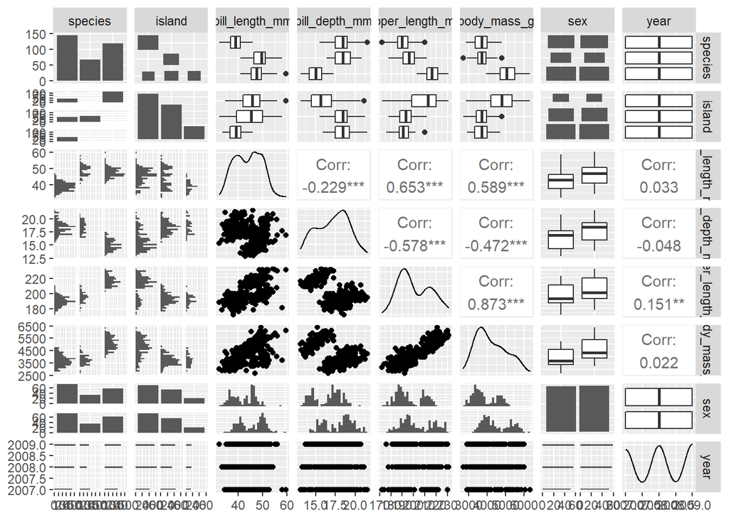

```r
model1 <- lm(bill_length_mm ~., data = penguins)
library(GGally)
GGally::ggpairs(penguins)
```

### Use `MASS::mvrnorm()` to simulate 100 observation of two predictor variables (x and z) with a given correlation. Simulate a response variable y = b0 + b1x + b2z. Test how the uncertainty in the coefficients changes with the correlation (and hence vif) of the predictor variables.

```r
# data info

Sigma = matrix(c(1, 0.9, 0.9, 1), 2, 2)
Sigma
```

```
##      [,1] [,2]
## [1,]  1.0  0.9
## [2,]  0.9  1.0
```

```r
a <- mvrnorm(n = 100, mu=c(1,1), Sigma) %>% as.data.frame() %>% mutate(y= V1 +V2 +rnorm(100))
a
```

```
##              V1           V2           y
## 1   -0.65159346 -0.615854977 -1.40711296
## 2    1.32936417  0.912519790  2.45695847
## 3    2.33078610  2.561432781  5.09337837
## 4    0.51907218  0.391212856  1.10376652
## 5    0.32418454  0.926554274  0.31059963
## 6    0.99631893  0.856979948  1.46621597
## 7    2.05563051  1.240195247  3.60415139
## 8    1.53132739  0.433161900  1.95472326
## 9    3.08241489  2.868484247  4.93077349
## 10   2.21097162  1.426737319  5.23962161
## 11   2.29566472  1.667630692  4.17507857
## 12   0.08243787  0.206942395 -0.39619076
## 13   1.91246836  2.172407599  4.26707552
## 14  -1.41443346 -1.492392439 -1.59800640
```

[output cut: 86 more lines]

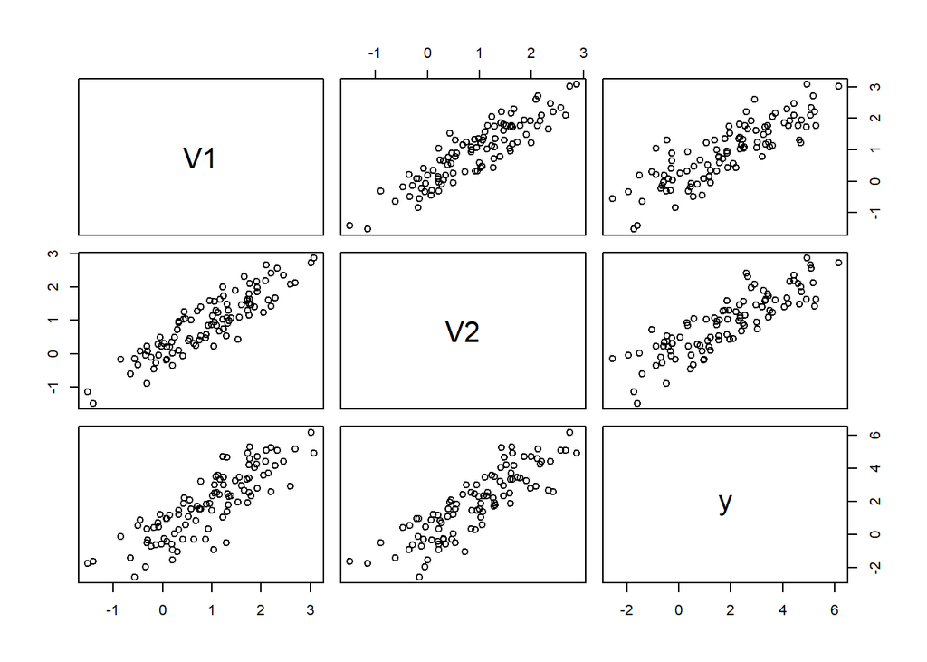

```r
plot(a)
```

```r
moda <- lm(y~., data=a)
olsrr::ols_vif_tol(moda)
```

```
##   Variables Tolerance     VIF
## 1        V1 0.1985226 5.03721
## 2        V2 0.1985226 5.03721
```